# TIME SERIES ANALYSIS

MAKINI Caleb

2026-09-24

```r
#setting a working directory

setwd("C:/Users/ADMIN/OneDrive/Desktop/caleb makini")
```

loading libraries

library(ggplot2) library(ggthemes) library(stats) library(forecast) library(tseries) library(formatR) library(papaja)>

simple time series test

data=data.frame( date=seq(as.Date(“2025-01-01”), as.Date(“2026-12-31”), by=“month”), value=c(100, 102, 141, 160, 128, 200, 202, 204, 260, 208, 300, 320, 250, 202, 140, 160, 138, 200, 202, 204, 265, 208, 359, 380))

head(data)>

```
        date value
1 2025-01-01   100
2 2025-02-01   102
3 2025-03-01   141
4 2025-04-01   160
5 2025-05-01   128
6 2025-06-01   200
```

convert date column to date format data$date<-as.Date(data$date) head(data)>

```
        date value
1 2025-01-01   100
2 2025-02-01   102
3 2025-03-01   141
4 2025-04-01   160
5 2025-05-01   128
6 2025-06-01   200
```

plot time series

ggplot(data, aes(x=date, y=value))+ geom_line(color=“blue”)+ labs( title=“time series data”, x=“date”, y=“value” )+ theme_minimal()>

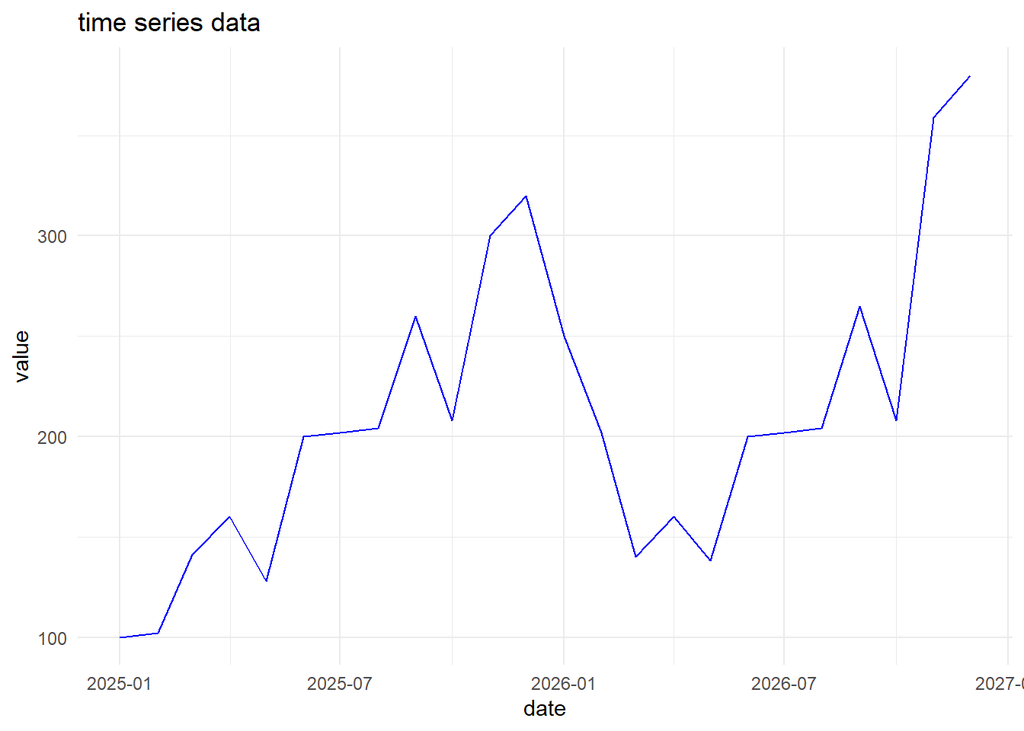

Decompose time series data

create a time series object

ts_data<-ts(data$value, frequency = 12, start = c(2025, 1))

decompose time series

decomposed_data<-decompose(ts_data)

plot the decompostion

plot(decomposed_data)>

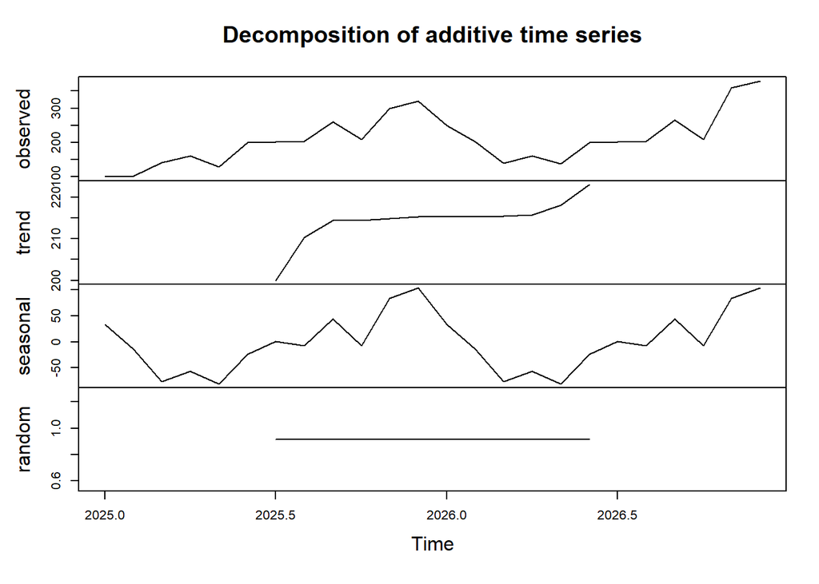

Autocorrelation function

acf(ts_data, lag.max=20)>

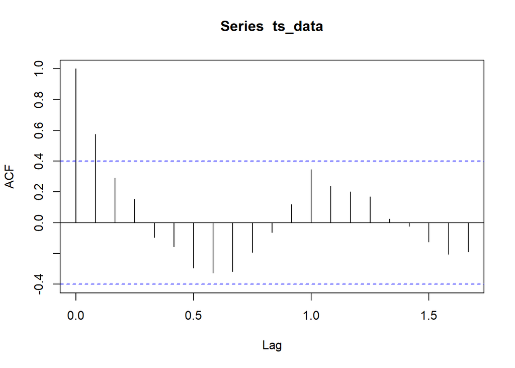

partial autocorrelation of data

pacf(ts_data, lag.max=20)>

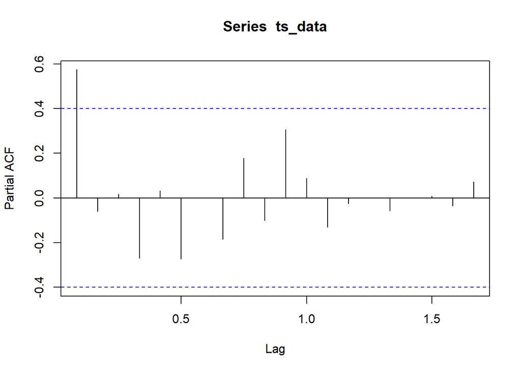

check stationality using (Augmented dickey Fuller test (ADF))

adf_results<-adf.test(ts_data) if p-value<5%, the series is stationary

print(adf_results)>

```
    Augmented Dickey-Fuller Test

data:  ts_data
Dickey-Fuller = -1.4364, Lag order = 2, p-value = 0.7871
alternative hypothesis: stationary
```

series not stationary since p-value is greater than 5%>

if p-value> 5%, we take first difference

diff_data<-diff(ts_data) plot(diff_data, main=” differenced time series data”, col=“red”)>

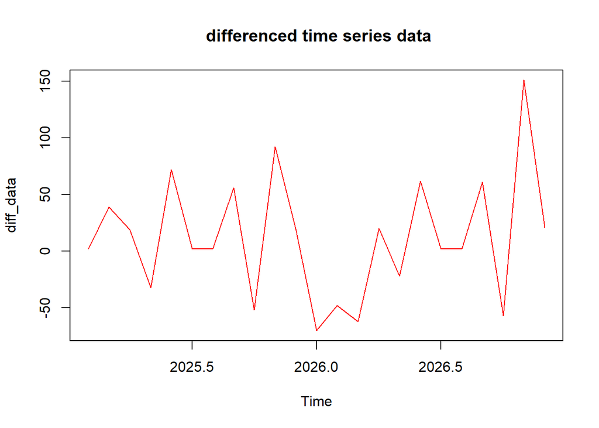

adf.test(diff_data)>

```
    Augmented Dickey-Fuller Test

data:  diff_data
Dickey-Fuller = -1.4537, Lag order = 2, p-value = 0.7805
alternative hypothesis: stationary
```

diff2_data<-diff(diff_data) diff3_data<-diff(diff2_data) diff4_data<-diff(diff3_data) plot(diff4_data, main=” differenced time series data”, col=“red”)>

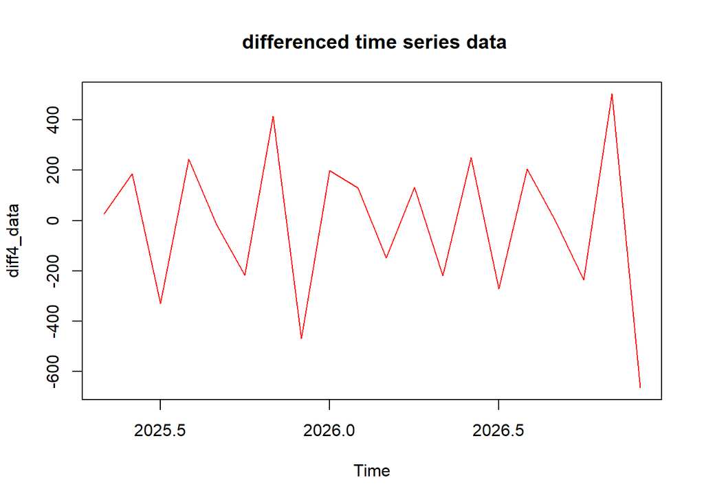

adf.test(diff4_data)>

```
    Augmented Dickey-Fuller Test

data:  diff4_data
Dickey-Fuller = -4.1327, Lag order = 2, p-value = 0.01863
alternative hypothesis: stationary
```

buid ana ARIMA model

fit arim,a model

arima_model<- auto.arima(diff4_data) summary(arima_model)>

```
Series: diff4_data
ARIMA(2,0,0) with zero mean

Coefficients:
          ar1      ar2
      -1.5190  -0.8801
s.e.   0.1048   0.0951

sigma^2 = 9662:  log likelihood = -121.1
AIC=248.21   AICc=249.71   BIC=251.19

Training set error measures:
                   ME     RMSE      MAE       MPE     MAPE      MASE       ACF1
Training set 2.459696 93.24984 74.28143 -372.5573 406.7952 0.8151598 -0.2279084
```

forecasting future format

forecast_arima<- forecast(arima_model, h=6) head(forecast_arima)>

```
$method
[1] "ARIMA(2,0,0) with zero mean"

$model
Series: diff4_data
ARIMA(2,0,0) with zero mean

Coefficients:
          ar1      ar2
      -1.5190  -0.8801
s.e.   0.1048   0.0951

sigma^2 = 9662:  log likelihood = -121.1
AIC=248.21   AICc=249.71   BIC=251.19

$level
[1] 80 95

$mean
            Jan        Feb        Mar        Apr        May        Jun
2027  565.88077 -275.13783  -80.13169  363.87823 -482.19113  412.16653

$lower
                80%        95%
Jan 2027  439.91199  373.22815
Feb 2027 -504.22295 -625.49329
Mar 2027 -371.33238 -525.48472
Apr 2027   54.44133 -109.36466
May 2027 -791.62892 -955.43540
Jun 2027   89.63132  -81.10851

$upper
                80%        95%
Jan 2027  691.84955 758.533396
Feb 2027  -46.05271  75.217634
Mar 2027  211.06901 365.221343
Apr 2027  673.31512 837.121114
May 2027 -172.75333  -8.946859
Jun 2027  734.70175 905.441575
```

forecast next 6 periods

plot(forecast_arima)>

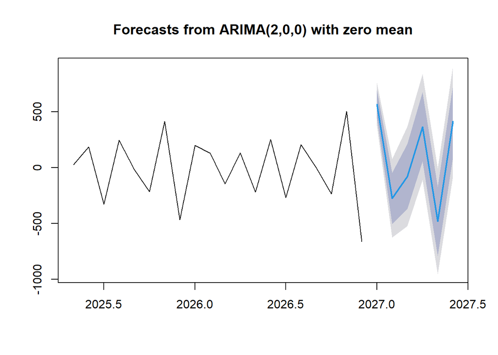